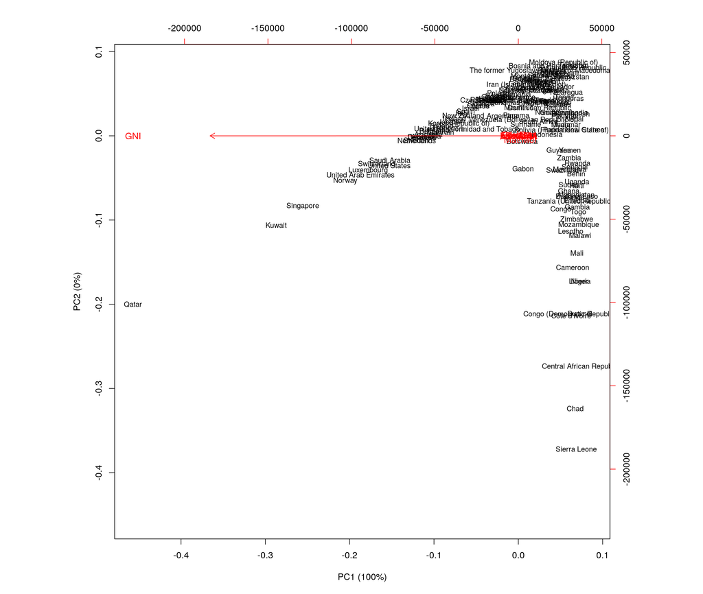

```r
s_no_standard=summary(pca_human_no_standard)

pca_pr_no_standard <- round(100*s_no_standard$importance[2, ], digits = 1)
pc_lab_no_standard=paste0(names(pca_pr_no_standard), " (", pca_pr_no_standard, "%)")

biplot(pca_human_no_standard, cex = c(0.8, 1), col = c("black", "red"), xlab = pc_lab_no_standard[1], ylab = pc_lab_no_standard[2])
```

```r
pca_human_standard <- prcomp(human,scale. = TRUE)
pca_human_standard
```

```
## Standard deviations (1, .., p=8):
## [1] 2.0708380 1.1397204 0.8750485 0.7788630 0.6619563 0.5363061 0.4589994
## [8] 0.3222406
##
## Rotation (n x k) = (8 x 8):
##                   PC1         PC2         PC3         PC4        PC5
## Edu2.FM   -0.35664370  0.03796058 -0.24223089  0.62678110 -0.5983585
## Labo.FM    0.05457785  0.72432726 -0.58428770  0.06199424  0.2625067
## Edu.Exp   -0.42766720  0.13940571 -0.07340270 -0.07020294  0.1659678
## Life.Exp  -0.44372240 -0.02530473  0.10991305 -0.05834819  0.1628935
## GNI       -0.35048295  0.05060876 -0.20168779 -0.72727675 -0.4950306
## Mat.Mor    0.43697098  0.14508727 -0.12522539 -0.25170614 -0.1800657
## Ado.Birth  0.41126010  0.07708468  0.01968243  0.04986763 -0.4672068
## Parli.F   -0.08438558  0.65136866  0.72506309  0.01396293 -0.1523699
##                   PC6         PC7         PC8
## Edu2.FM    0.17713316  0.05773644  0.16459453
## Labo.FM   -0.03500707 -0.22729927 -0.07304568
## Edu.Exp   -0.38606919  0.77962966 -0.05415984
## Life.Exp  -0.42242796 -0.43406432  0.62737008
## GNI        0.11120305 -0.13711838 -0.16961173
## Mat.Mor    0.17370039  0.35380306  0.72193946
## Ado.Birth -0.76056557 -0.06897064 -0.14335186
## Parli.F    0.13749772  0.00568387 -0.02306476
```

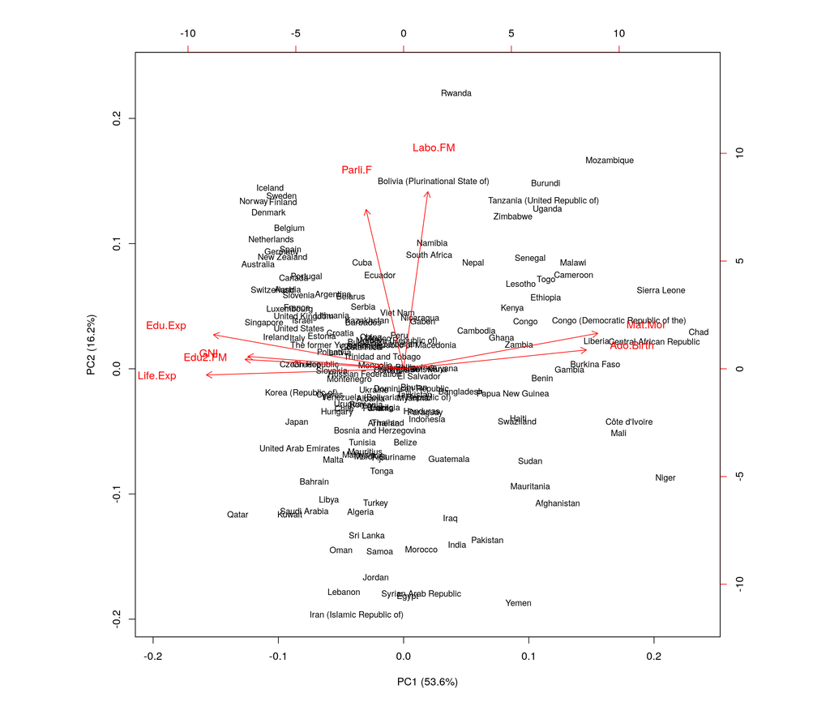

```r
s_standard=summary(pca_human_standard)

pca_pr_standard <- round(100*s_standard$importance[2, ], digits = 1)

pc_lab_standard=paste0(names(pca_pr_standard), " (", pca_pr_standard, "%)")

biplot(pca_human_standard, cex = c(0.8, 1), col = c("black", "red"), xlab = pc_lab_standard[1], ylab = pc_lab_standard[2])
```

There is a big difference between the results of PCA with and without standardizing data. As it is explained in the slide “PCA is sensitive to the relative scaling of the original features and assumes that features with larger variance are more important than features with smaller variance”. Hence Performing PCA on unstandardized variables will results to large loadings for variables with larger variance.For example: From the summary table, we can clearly see that among eight variables, the GIN variable has a large variance. this will lead to dependence of a principal component on the GIN variable with high variance. You can see, first principal component is dominated by a variable GIN.PC1 explains nearly all of the variance (99.99%).

When the variables are scaled, we get a much better representation of variables.The first two principal components explained about ~70% of the variance. The first principal component (PC1) explains 53.% of the variation compared to 100% when the data was not scaled.The second principal component (PC2) explains 16.2% of the variance.

### **The Tea dataset**

The tea data we are dealing in this week exercise comes from comes the R package “FactoMineR”. It is data frame with 300 rows and 36 columns. The data used here came from the survey conducted on a sample of 300 tea consumers.

```r
data("tea")
str(tea)
```

```
## 'data.frame':    300 obs. of  36 variables:
##  $ breakfast       : Factor w/ 2 levels "breakfast","Not.breakfast": 1 1 2 2 1 2 1 2 1 1 ...
##  $ tea.time        : Factor w/ 2 levels "Not.tea time",..: 1 1 2 1 1 1 2 2 2 1 ...
##  $ evening         : Factor w/ 2 levels "evening","Not.evening": 2 2 1 2 1 2 2 1 2 1 ...
##  $ lunch           : Factor w/ 2 levels "lunch","Not.lunch": 2 2 2 2 2 2 2 2 2 2 ...
##  $ dinner          : Factor w/ 2 levels "dinner","Not.dinner": 2 2 1 1 2 1 2 2 2 2 ...
##  $ always          : Factor w/ 2 levels "always","Not.always": 2 2 2 2 1 2 2 2 2 2 ...
##  $ home            : Factor w/ 2 levels "home","Not.home": 1 1 1 1 1 1 1 1 1 1 ...
##  $ work            : Factor w/ 2 levels "Not.work","work": 1 1 2 1 1 1 1 1 1 1 ...
##  $ tearoom         : Factor w/ 2 levels "Not.tearoom",..: 1 1 1 1 1 1 1 1 1 2 ...
##  $ friends         : Factor w/ 2 levels "friends","Not.friends": 2 2 1 2 2 2 1 2 2 2 ...
##  $ resto           : Factor w/ 2 levels "Not.resto","resto": 1 1 2 1 1 1 1 1 1 1 ...
##  $ pub             : Factor w/ 2 levels "Not.pub","pub": 1 1 1 1 1 1 1 1 1 1 ...
##  $ Tea             : Factor w/ 3 levels "black","Earl Grey",..: 1 1 2 2 2 2 2 1 2 1 ...
##  $ How             : Factor w/ 4 levels "alone","lemon",..: 1 3 1 1 1 1 1 3 3 1 ...
```

[output cut: 22 more lines]

```r
dim(tea)
```

```
## [1] 300  36
```

```r
#g1<-gather(tea) %>% ggplot(aes(value)) + facet_wrap("key", scales = "free")
#g1+ geom_bar() + theme(axis.text.x = element_text(angle = 45, hjust = 1, size = 8))

summary(tea)
```

```
##          breakfast           tea.time          evening          lunch
##  breakfast    :144   Not.tea time:131   evening    :103   lunch    : 44
##  Not.breakfast:156   tea time    :169   Not.evening:197   Not.lunch:256
##
##
##
##
##
##         dinner           always          home           work
##  dinner    : 21   always    :103   home    :291   Not.work:213
##  Not.dinner:279   Not.always:197   Not.home:  9   work    : 87
##
##
##
##
##
##         tearoom           friends          resto          pub
##  Not.tearoom:242   friends    :196   Not.resto:221   Not.pub:237
##  tearoom    : 58   Not.friends:104   resto    : 79   pub    : 63
##
##
##
##
##
##         Tea         How           sugar                     how
##  black    : 74   alone:195   No.sugar:155   tea bag           :170
##  Earl Grey:193   lemon: 33   sugar   :145   tea bag+unpackaged: 94
##  green    : 33   milk : 63                  unpackaged        : 36
##                  other:  9
##
##
##
##                   where                 price          age        sex
##  chain store         :192   p_branded      : 95   Min.   :15.00   F:178
##  chain store+tea shop: 78   p_cheap        :  7   1st Qu.:23.00   M:122
##  tea shop            : 30   p_private label: 21   Median :32.00
##                             p_unknown      : 12   Mean   :37.05
##                             p_upscale      : 53   3rd Qu.:48.00
##                             p_variable     :112   Max.   :90.00
##
```

[output cut: 25 more lines]

```
##  feminine    :129   Not.sophisticated: 85   No.slimming:255
##  Not.feminine:171   sophisticated    :215   slimming   : 45
##
##
##
##
##
##         exciting          relaxing              effect.on.health
##  exciting   :116   No.relaxing:113   effect on health   : 66
##  No.exciting:184   relaxing   :187   No.effect on health:234
##
##
##
##
##
```

Among 36 columns (variables), I choose the following variables:

```r
#select my interest of variables
keep_columns <-  c("Tea", "home", "sugar", "always", "lunch","slimming", "health")
#my interest of  new dataset
tea_my <- dplyr::select(tea, one_of(keep_columns))
str(tea_my)
```

```
## 'data.frame':    300 obs. of  6 variables:
##  $ Tea     : Factor w/ 3 levels "black","Earl Grey",..: 1 1 2 2 2 2 2 1 2 1 ...
##  $ home    : Factor w/ 2 levels "home","Not.home": 1 1 1 1 1 1 1 1 1 1 ...
##  $ sugar   : Factor w/ 2 levels "No.sugar","sugar": 2 1 1 2 1 1 1 1 1 1 ...
##  $ always  : Factor w/ 2 levels "always","Not.always": 2 2 2 2 1 2 2 2 2 2 ...
##  $ lunch   : Factor w/ 2 levels "lunch","Not.lunch": 2 2 2 2 2 2 2 2 2 2 ...
##  $ slimming: Factor w/ 2 levels "No.slimming",..: 1 1 1 1 1 1 1 1 1 1 ...
```

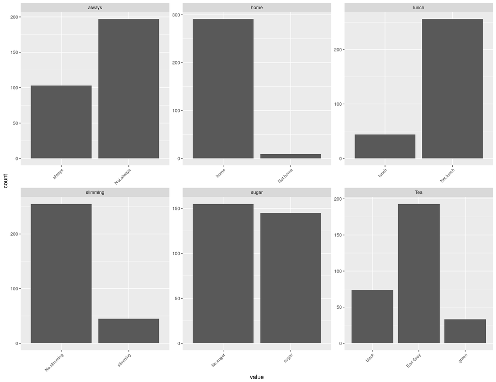

```r
g1<-gather(tea_my) %>% ggplot(aes(value)) + facet_wrap("key", scales = "free")
g1+ geom_bar() + theme(axis.text.x = element_text(angle = 45, hjust = 1, size = 8))
```

```r
summary(tea_my)
```

```
##         Tea            home          sugar            always
##  black    : 74   home    :291   No.sugar:155   always    :103
##  Earl Grey:193   Not.home:  9   sugar   :145   Not.always:197
##  green    : 33
##        lunch            slimming
##  lunch    : 44   No.slimming:255
##  Not.lunch:256   slimming   : 45
##
```

```r
# multiple correspondence analysis
mca <- MCA(tea_my, graph = FALSE)
# summary of the model
summary(mca)
```

```
##
## Call:
## MCA(X = tea_my, graph = FALSE)
##
##
## Eigenvalues
##                        Dim.1   Dim.2   Dim.3   Dim.4   Dim.5   Dim.6
## Variance               0.224   0.190   0.175   0.165   0.149   0.140
## % of var.             19.213  16.293  14.997  14.152  12.759  11.962
## Cumulative % of var.  19.213  35.506  50.503  64.655  77.414  89.376
##                        Dim.7
## Variance               0.124
## % of var.             10.624
## Cumulative % of var. 100.000
##
## Individuals (the 10 first)
##               Dim.1    ctr   cos2    Dim.2    ctr   cos2    Dim.3    ctr
## 1          | -0.262  0.102  0.082 | -0.225  0.089  0.060 |  0.321  0.197
## 2          | -0.734  0.801  0.661 | -0.149  0.039  0.027 |  0.379  0.274
## 3          | -0.142  0.030  0.051 | -0.183  0.059  0.084 |  0.092  0.016
## 4          |  0.330  0.162  0.259 | -0.260  0.118  0.160 |  0.034  0.002
## 5          |  0.022  0.001  0.001 |  0.275  0.133  0.120 | -0.395  0.298
## 6          | -0.142  0.030  0.051 | -0.183  0.059  0.084 |  0.092  0.016
## 7          | -0.142  0.030  0.051 | -0.183  0.059  0.084 |  0.092  0.016
## 8          | -0.734  0.801  0.661 | -0.149  0.039  0.027 |  0.379  0.274
## 9          | -0.142  0.030  0.051 | -0.183  0.059  0.084 |  0.092  0.016
## 10         | -0.734  0.801  0.661 | -0.149  0.039  0.027 |  0.379  0.274
##              cos2
## 1           0.123 |
## 2           0.176 |
## 3           0.021 |
## 4           0.003 |
## 5           0.248 |
## 6           0.021 |
## 7           0.021 |
## 8           0.176 |
## 9           0.021 |
## 10          0.176 |
##
## Categories (the 10 first)
```

[output cut: 16 more lines]

```
## Not.home    -2.762 |   2.721  21.165   0.229   8.276 |
## No.sugar     1.721 |   0.070   0.243   0.005   1.256 |
## sugar       -1.721 |  -0.075   0.260   0.005  -1.256 |
## always       9.844 |  -0.803  21.099   0.337 -10.043 |
## Not.always  -9.844 |   0.420  11.032   0.337  10.043 |
## lunch        1.071 |   0.612   5.227   0.064   4.385 |
##
## Categorical variables (eta2)
##              Dim.1 Dim.2 Dim.3
## Tea        | 0.552 0.232 0.392 |
## home       | 0.231 0.026 0.229 |
## sugar      | 0.449 0.010 0.005 |
## always     | 0.049 0.324 0.337 |
## lunch      | 0.054 0.004 0.064 |
## slimming   | 0.010 0.545 0.022 |
```

About 50.5 % of the variation is captured by first three dimensions, firs one capturing 19.21% of the variance, second one 16.29% and third one 14.99% of the variance.The Categorical variables shows the squared correlations between the variables and dimensions. Type of Tea has strong squared correlation to first dimension (0.552) and modest squared correlation to both dimensions two (0.232) and three (0.392 ). slimming has strong squared correlation to dimension two (0.545) and smallest squared correlation to both dimensions one (0.010) and three (0.022).

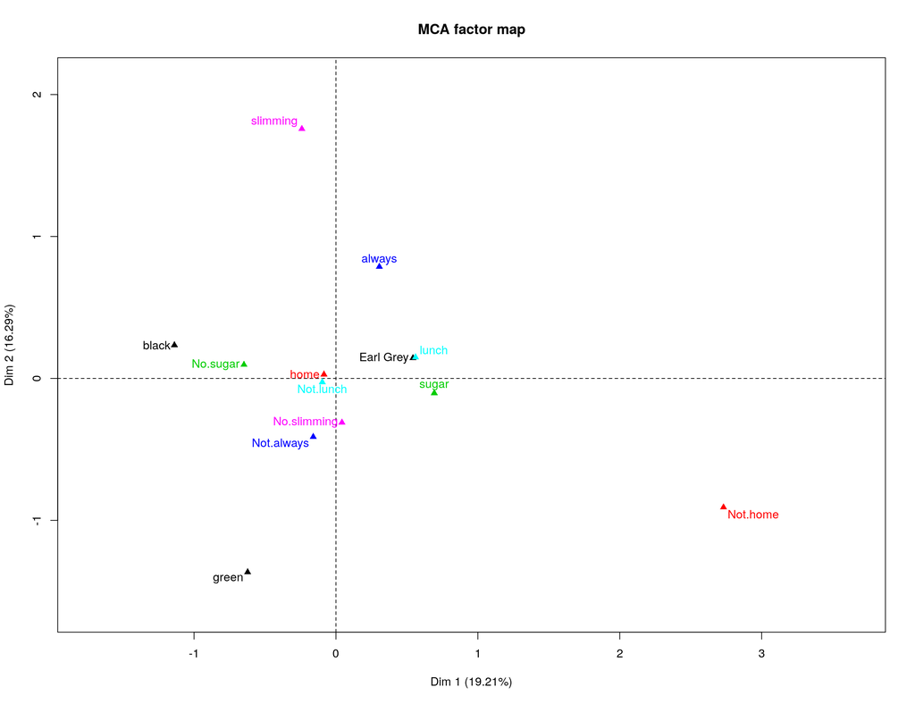

```r
# visualize MCA
plot(mca, invisible=c("ind"),habillage = "quali")
```